# 05. Summarizing Data

## The summarize verb

In the previous chapter we introduced the concept of data *verbs*. Four useful examples were shown: `slice` and `filter` for taking a subset of rows, `select` for taking a subset of columns, and `arrange` for reordering a dataset’s rows. In this chapter we discuss another important verb, `summarize`, that collapses a data frame by using summary functions. Using this verb is slightly more involved because we have to explain exactly how the data should be summarized. We will introduce several helper functions to make this process slightly easier.

Before describing the syntax for the summarize function, let’s start with an example. Here, we summarize our food dataset by indicating the mean (average) value of the sugar variable across the entire dataset:

```r
food %>%
  summarize(sm_mean(sugar))
```

```
## # A tibble: 1 x 1
##   sugar_mean
##        <dbl>
## 1       3.42
```

In order to compute multiple summaries at once, we can pass multiple functions together are once. For example, here we compute the mean value of three nutritional measurments:

```r
food %>%
  summarize(sm_mean(sugar), sm_mean(calories), sm_mean(vitamin_a))
```

```
## # A tibble: 1 x 3
##   sugar_mean calories_mean vitamin_a_mean
##        <dbl>         <dbl>          <dbl>
## 1       3.42          114.           16.1
```

Notice that R creates a new dataset and intelligently chooses the variable names. There are a number of other useful summary functions that work similarly, such as `sm_min`, `sm_max`, `sm_sum`, and `sm_sd` (standard deviation).

## Multiple output values

Some summary functions return multiple columns for a given variable. For example, `sm_quartiles` gives the *five-number summary* of a variable: its minimum value, the first quartile (25th percentile), the median (50th percentile), the third quartile (75th percentile), and the maximum value. As with the other summary functions, smart variable names are automatically created in R:

```r
food %>%
  summarize(sm_quartiles(calories))
```

```
## # A tibble: 1 x 5
##   calories_min calories_q1 calories_median calories_q3 calories_max
##          <dbl>       <dbl>           <dbl>       <dbl>        <dbl>
## 1           12          34              87         171          389
```

Functions such as `sm_deciles` and `sm_percentiles` give a similar output, but with additional cutoff values. These can be useful in trying to describe the distribution of numeric variables in large datasets.

The final group of summary functions that we will use provide *confidence intervals*. These provide the mean of a variable as well as an upper and lower bound for the mean using properties from statistical inference. Here, for example, is how we use the `sm_mean_cl_normal` to produce a confidence interval for the mean of the calories variable:

```r
food %>%
  summarize(sm_mean_cl_normal(calories), sm_count())
```

```
## # A tibble: 1 x 4
##   calories_mean calories_ci_min calories_ci_max count
##           <dbl>           <dbl>           <dbl> <int>
## 1          114.            90.0            137.    61
```

A more detailed discussion the specifics of the assumptions and models underlying confidence intervals is given in Chapter 20.

## Grouped summaries

Summarizing the dataset to a single row can be useful for understanding the general trends in a dataset or highlighting outliers. However, the real power of the summary function comes when we pair it with grouped manipulations. This will allow us to produce summaries *within* one or more grouping variables in our dataset.

When we use the `group_by` function, subsequent uses of the `summarize` function will produce a summary that describes the properties of variables within the variable used for grouping. The variable name(s) placed inside of the `group_by` function indicate which variable(s) should be used for the groups. For example, here we compute the mean number of calories of each food group:

```r
food %>%
  group_by(food_group) %>%
  summarize(sm_mean(calories))
```

```
## # A tibble: 6 x 2
##   food_group calories_mean
##   <chr>              <dbl>
## 1 dairy              181.
## 2 fish               167.
## 3 fruit               54.9
## 4 grains             196.
## 5 meat               234.
## 6 vegetable           37.4
```

Notice that the output dataset contains a column for the grouping variable (`food_group`) and the summarized variable (`calories_mean`). The summarized variable name is exactly the same as the non-grouped version and the final line of code looks exactly the same as before. However, the output dataset now contains six rows, one for each food group.

Any summarization function that can be used for an ungrouped dataset can also be used for a grouped dataset. Also, as before, we can put multiple summary functions together to obtain different measurements of each group.

```r
food %>%
  group_by(food_group) %>%
  summarize(sm_mean(calories), sm_mean(total_fat))
```

```
## # A tibble: 6 x 3
##   food_group calories_mean total_fat_mean
##   <chr>              <dbl>          <dbl>
## 1 dairy              181.          13.0
## 2 fish               167.           7.22
## 3 fruit               54.9          1.04
## 4 grains             196.           2.56
## 5 meat               234.          13.9
## 6 vegetable           37.4          0.281
```

Notice that the automatically produced variable names should make it clear which column corresponds to each summary function.

## More summary functions

There are several additional summary functions that will be useful for analyzing data. The function `sm_count` takes no arguments and returns a variable called `count` that counts the total number of rows in the dataset:

```r
food %>%
  group_by(food_group) %>%
  summarize(sm_count())
```

```
## # A tibble: 6 x 2
##   food_group count
##   <chr>      <int>
## 1 dairy          4
## 2 fish          14
## 3 fruit         16
## 4 grains         5
## 5 meat           6
## 6 vegetable     16
```

This tells us how many times each type of food group occurs in the dataset. Similarly, the function `sm_na_count` tells us how many values of a variable are missing:

```r
food %>%
  group_by(food_group) %>%
  summarize(sm_count(), sm_na_count(calories))
```

```
## # A tibble: 6 x 3
##   food_group count calories_na_count
##   <chr>      <int>             <int>
## 1 dairy          4                 0
## 2 fish          14                 0
## 3 fruit         16                 0
## 4 grains         5                 0
## 5 meat           6                 0
## 6 vegetable     16                 0
```

In this case there are no missing values for the `calories` variable.

The summary function `sm_paste` collapses all of the values in a character variable. For example, applying this summary it to the `item` category after grouping by color, we can see all of the foods in the dataset associated with a specific color:

```r
food %>%
  group_by(color) %>%
  summarize(sm_paste(item))
```

```
## # A tibble: 8 x 2
##   color  item_paste
##   <chr>  <fct>
## 1 brown  Chickpea; Mushroom; Oat; Quinoa; Brown Rice
## 2 green  Asparagus; Avocado; String Bean; Bell Pepper; Broccoli; Cabbage; Celer…
## 3 orange Cantaloupe; Carrot; Orange; Sweet Potato; Tangerine
## 4 pink   Grapefruit; Peach; Salmon; Shrimp
## 5 purple Grape; Plum
## 6 red    Apple; Beef; Crab; Duck; Lamb; Lobster; Strawberry; Tomato; Tuna
## 7 white  Catfish; Cauliflower; Chicken; Clam; Cod; Flounder; Halibut; Haddock; …
## 8 yellow Banana; Cheese; Corn; Lemon; Pineapple
```

Do the foods correspond to the colors that you would expect?

## Geometries for summaries

We can use summarized datasets to produce new data visualizations. For example, consider summarizing the average number of calories, average total fat, and number of items in each food groups. We can take this data and construct a scatter plot that shows the average fat and calories of each food group, along with informative labels. Here’s the code to make this visualization:

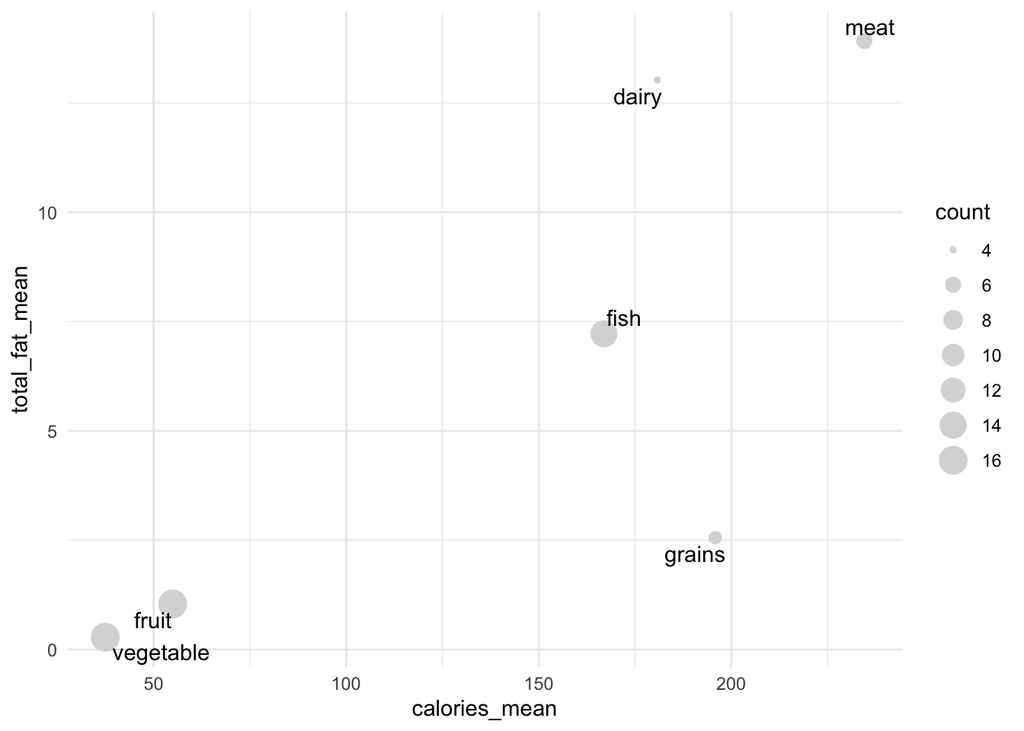

```r
food %>%
  group_by(food_group) %>%
  summarize(sm_mean(calories), sm_mean(total_fat), sm_count()) %>%
  ggplot() +
    geom_point(aes(x = calories_mean, y = total_fat_mean, size = count), color = "grey85") +
    geom_text_repel(aes(x = calories_mean, y = total_fat_mean, label = food_group))
```

If this seems complex, don’t worry! We are just putting together elements that we have already covered, but it takes some practice before it becomes natural.

Scatterplots are often useful for displaying summarized information. There are two additional `geom` types that often are useful specifically for the case of summarized datasets.

If we want to create a bar plot, where the heights of the bars as given by a column in the dataset, we can use the `geom_col` layer type. For this, assign a categorical variable to the `x`-aesthetic and the count variable to the `y`-aesthetic. For example, here is a bar plot showing the number of items in each food group:

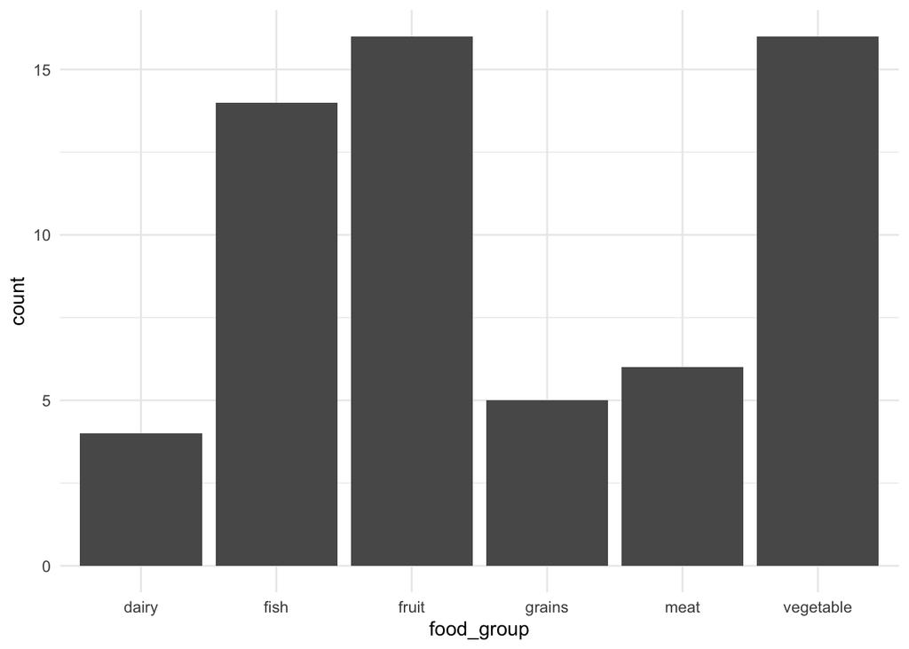

```r
food %>%
  group_by(food_group) %>%
  summarize(sm_count()) %>%
  ggplot() +
    geom_col(aes(x = food_group, y = count))
```

There are two specific things to keep in mind with the `geom_col` layer. First, there are two color-related `aes` categories: the border of the bars (`color`) and the color used to shade the inside of the bars (`fill`). We can change these exactly as we did with the single color value used with scatter plots. Also, if we want to produce a bar plot with horizontal bars, this can be done by adding the special layer `coord_flip()` at the end of the plotting command.

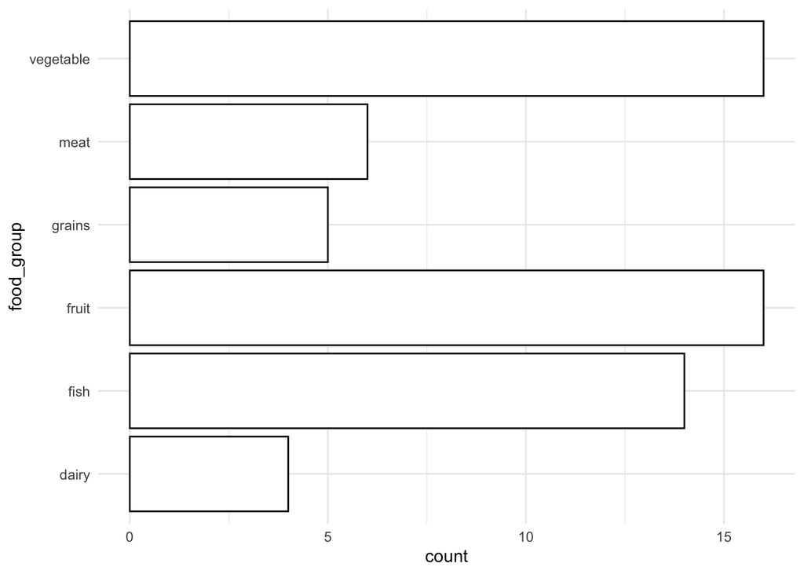

```r
food %>%
  group_by(food_group) %>%
  summarize(sm_count()) %>%
  ggplot() +
    geom_col(aes(x = food_group, y = count), color = "black", fill = "white") +
    coord_flip()
```

I find that using a white fill color and a black border is often a good-looking starting point. Also, you will notice that making the bars horizontal will make it easier to read the category names when there are a larger number of categories.

There is also a specific geometry that is useful when visualizing confidence intervals called `geom_pointrange`. It requires a categorical `x`-aesthetic, a numeric `y`-aesthetic, and two additional numeric aesthetics: `ymin` and `ymax`. This produced a visual confidence interval from the minimum value to the maximum value, with the middle value shown by a solid point:

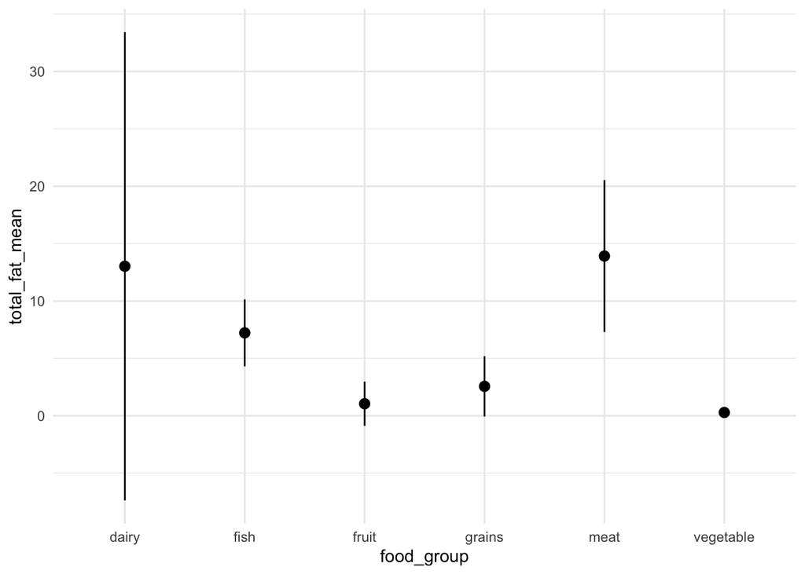

```r
food %>%
  group_by(food_group) %>%
  summarize(sm_mean_cl_normal(total_fat)) %>%
  ggplot() +
    geom_pointrange(aes(
      x = food_group,
      y = total_fat_mean,
      ymin = total_fat_ci_min,
      ymax = total_fat_ci_max
    ))
```

Here, we see that vegetables have a low amount of total fat, meats have a relatively large amount of fat, and the confidence interval for dairy products is very large (in this case, it is because there are not many dairy products in the dataset). As with the barplot, we can draw the confidence intervals horizontally by adding a `coord_flip()` layer to the plot.

## Multiple groups

As mentioned above, it is possible to group a dataset by multiple variables. To do this, we can provide additional variables to the `group_by` function separated by commas. For example, we could group the food dataset into food group and color, and summarize each combination of the two:

```r
food %>%
  group_by(food_group, color) %>%
  summarize(sm_count(), sm_mean(calories))
```

```
## # A tibble: 21 x 4
## # Groups:   food_group [6]
##    food_group color  count calories_mean
##    <chr>      <chr>  <int>         <dbl>
##  1 dairy      white      3         124.
##  2 dairy      yellow     1         350
##  3 fish       pink       2         158.
##  4 fish       red        3         112.
##  5 fish       white      9         187.
##  6 fruit      green      4          77.2
##  7 fruit      orange     3          44.7
##  8 fruit      pink       2          35.5
##  9 fruit      purple     2          57.5
## 10 fruit      red        2          42
## # … with 11 more rows
```

Notice that now there is one row for each combination of the two groups. However, there is no row for combinations that do not exist. So, there is no row for pink dairy products nor for white fruit. Examples of several common uses for multiple groups are given in the exercises.

## Exercises and References

There is are exercise notebook for this chapter:

- **exercies05A.Rmd**: practice applying summary functions to a new dataset
- **exercies05B.Rmd**: open-ended questions to explore with data

It is strongly recommended to complete at least the first notebook prior to continuing on to the next chapter.

Here are several good resources if you want to learn more about the Grammar of Graphics in R:

- [R for Data Science: Chapter 5](https://r4ds.had.co.nz/transform.html)
- [dplyr cheatsheet](https://github.com/rstudio/cheatsheets/raw/master/data-transformation.pdf)
- [dplyr homepage](https://dplyr.tidyverse.org/)

If you search online for help with R graphics, make sure to add the term “dplyr” to your query as otherwise you may find advice for using other functions that are not easily compatible with the approach described here.